# Notebook

```python
import importlib
from typing import Dict, Tuple
from matplotlib import pyplot as plt
from shared.definitions import TuningResult

from shared import stats_utils
from shared.ml_config_runner import build_production_model_for_tuning_result
from shared import graph
from shared import utils
import seaborn as sns
import pandas as pd
import xgboost
from Draft import feature_builder_v2
import importlib
import xgboost as xgb
import shared.ml_config_core as ml_config_core
import src_draft.utils as local_utils
from IPython.display import Markdown
import shap

VERBOSE = False
utils.pandas_config(pd)
utils.plt_config(plt)

sns.set_theme(style="darkgrid", palette="pastel")
plt.style.use("fivethirtyeight")
import numpy as np
```

#### Selecting Best Performing Model

The table compares several different configurations of an LGBM model (based on tuning metric and included features).

##### Test Sample:

```python
model_results_df = pd.read_csv("data/results_all_models_test.csv")
utils.create_styled_df(model_results_df, 0, decimals=2, include_cols = ["Model", "auc", "pr_auc", "target_f1", "target_recall", "target_precision", "log_loss", "elapsed_time", "total_size"])
```

|  | Model | auc | pr_auc | target_f1 | target_recall | target_precision | log_loss | elapsed_time | total_size |
| --- | --- | --- | --- | --- | --- | --- | --- | --- | --- |
| 0 | LGBM_Dart_AUC | 0.79 | 0.28 | 0.32 | 0.68 | 0.21 | 0.51 | 104.60 | 14.45 |
| 1 | LGBM_AUC | 0.79 | 0.28 | 0.30 | 0.70 | 0.20 | 0.53 | 53.10 | 13.44 |
| 2 | LGBM_AUC_All_Features | 0.78 | 0.28 | 0.30 | 0.69 | 0.19 | 0.54 | 47.20 | 21.34 |
| 3 | LGBM_AUC_Base_Features | 0.76 | 0.26 | 0.28 | 0.67 | 0.17 | 0.57 | 14.60 | 11.28 |
| 4 | LGBM_Weighted_LogLoss | 0.75 | 0.24 | 0.28 | 0.67 | 0.17 | 0.61 | 11.50 | 5.73 |
| 5 | Baseline_Only_CreditRatings | 0.73 | 0.21 | 0.25 | 0.66 | 0.15 | 0.61 | 2.10 | 1.16 |

```
* elapsed time - training time in second (~24 core CPU)
* total_size - model deployment binary size in (MB)
```

##### 5-Fold CV:

```python
model_results_df = pd.read_csv("data/results_all_models_validation.csv")
utils.create_styled_df(model_results_df, 0, decimals=2, include_cols = ["Model", "auc", "pr_auc", "target_f1", "target_recall", "target_precision"])
```

|  | Model | auc | pr_auc | target_f1 | target_recall | target_precision |
| --- | --- | --- | --- | --- | --- | --- |
| 0 | LGBM_Dart_AUC | 0.78 | 0.26 | 0.29 | 0.66 | 0.19 |
| 1 | LGBM_AUC | 0.77 | 0.26 | 0.29 | 0.66 | 0.19 |
| 2 | LGBM_AUC_All_Features | 0.77 | 0.26 | 0.29 | 0.66 | 0.19 |
| 3 | LGBM_AUC_Base_Features | 0.76 | 0.24 | 0.27 | 0.66 | 0.17 |
| 4 | LGBM_Weighted_LogLoss | 0.76 | 0.24 | 0.28 | 0.61 | 0.18 |
| 5 | Baseline_Only_CreditRatings | 0.72 | 0.20 | 0.24 | 0.66 | 0.15 |

We have selected `LGBM_Dart_AUC` as our final "production" model. LightGBM be default issues 'GBDT' (Gradient Boosting Decision Tree) as its boosting algorithm. 'DART' (Dropouts meet Multiple Additive Regression Trees ) is an alternativeboosting algorithm variant that helps prevent overfitting and improve model generalization by randomly dropping a fraction of boosting trees during training (similar to dropout in neural networks).

Because DART's process of dropping and adding trees back into the model requires more computational work and longer training periods, additionally the stochastic nature of the dropout process can lead to less consistent performance across different training runs compared to GBDT which might be problematic when tuning.

However, we have chose to use LGBM + DART as our primary model because it provides slightly better performance and it's theoretical advantages (reduce overfitting and better Generalization) outweigh the slower training time (5 fold CV + fitting a model on the full train set only take ~2 minutes).

```python
importlib.reload(ml_config_core)

# Use to selection different model to analyze:
SELECTED_MODEL_KEY = "LGBM_Dart_AUC"
# SELECTED_MODEL_KEY = "LGBM_AUC"
BASELINE_MODEL_KEY = "Baseline_Only_CreditRatings"

selected_model: ml_config_core.ModelTrainingResult = (
    ml_config_core.ModelTrainingResult.load_serialize_model(SELECTED_MODEL_KEY)
)

selected_model_pipeline_info: TuningResult = TuningResult.load_serialized_tuning_result(
    SELECTED_MODEL_KEY
)

baseline_model: ml_config_core.ModelTrainingResult = (
    ml_config_core.ModelTrainingResult.load_serialize_model(BASELINE_MODEL_KEY)
)

results_all_models = {
    SELECTED_MODEL_KEY: selected_model,
    # Uncomment to include alternative models
    # SELECTED_MODEL_ALT_KEY: selected_model_alt,
    BASELINE_MODEL_KEY: baseline_model,
}
```

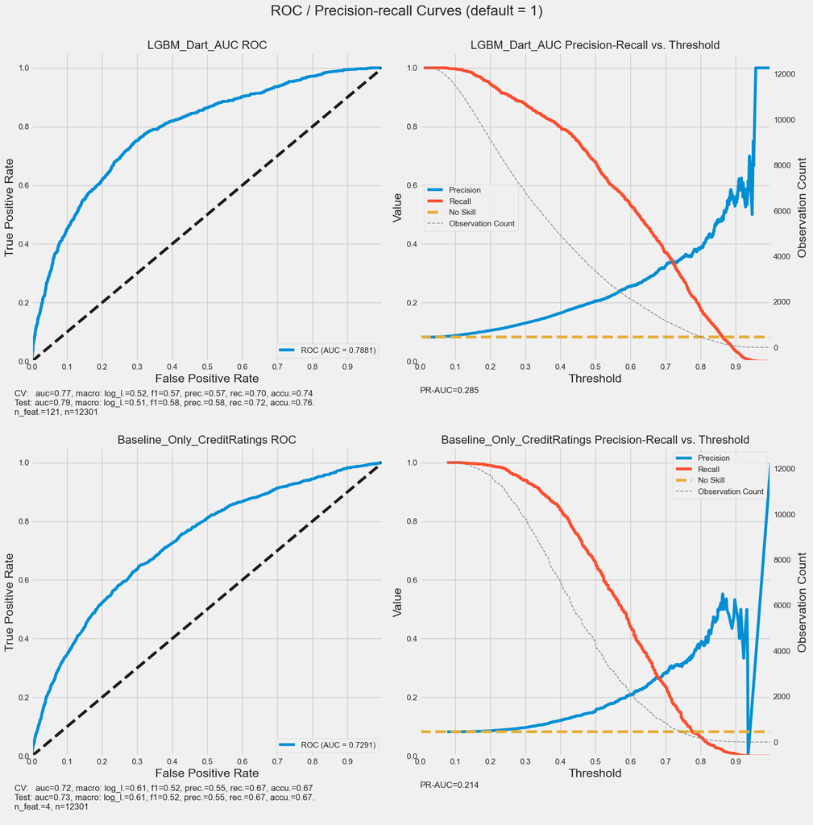

```python
importlib.reload(graph)

graph.roc_precision_recal_grid_plot(results_all_models, show_observation_count=True)
```

[figure not shown]

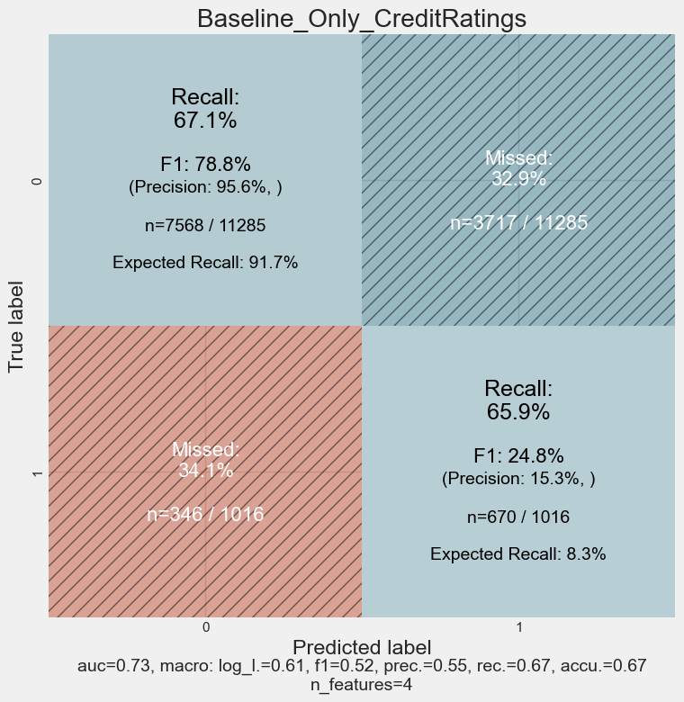

```python
importlib.reload(graph)

for model_key, _selected_model in results_all_models.items():
    graph.confusion_matrix_plot_v2(
        _selected_model.cm_data,
        title=model_key,
        annotations=graph.make_annotations(
            _selected_model.test_data.metrics_2,
            n_feats=len(_selected_model.cm_data.x_test.columns),
        ),
    )

plt.show()
```

On the other hand a somewhat large proportion of (~65%) of problematic loans were detected as such, considering the inherent risks of catering to clients with poorly know credit history that's a relative reasonable result.

We'll investigate this further but generally we can see that the model might be useful to Home Credit if they decided to take a more conservative approach to granting loans.

```python
from shared import pipeline

features_matrix = selected_model_pipeline_info.model_pipeline_config.load_data(
    loader_function=feature_builder_v2.load_datasets_and_prepare_features
)

X_train, X_test, y_train, y_test = pipeline.get_deterministic_train_test_split(
    features_matrix
)
X_train = X_train.drop(columns=["TARGET"])
X_test = X_test.drop(columns=["TARGET"])

model = selected_model.test_data.test_model.named_steps["model"]
prob_pos = model.predict_proba(X_test)[:, 1]
```

```python
prob_pos_series = pd.Series(prob_pos, index=y_test.index, name="TARGET")
```

#### Feature Importance

```python
model = selected_model.test_data.test_model.named_steps["model"]
prob_pos = model.predict_proba(X_test)[:, 1]
```

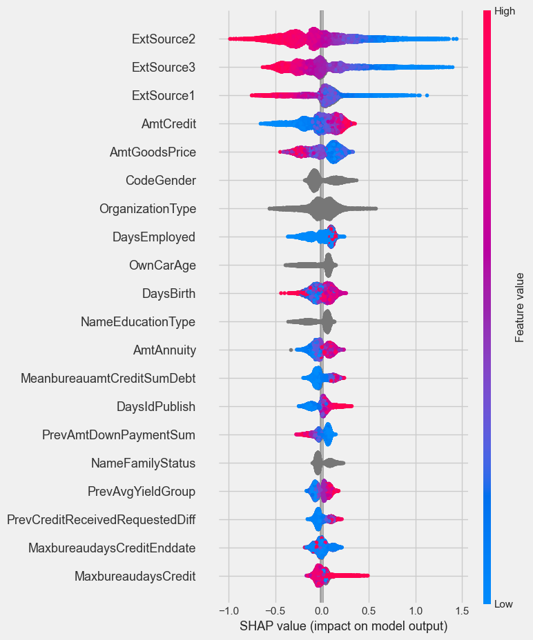

```python
explainer = shap.TreeExplainer(model)
shap_values = explainer.shap_values(X_test)
shap.summary_plot(shap_values, X_test)
```

```
*they grey colored features are nominal/categorical and don't have high/low values.
```

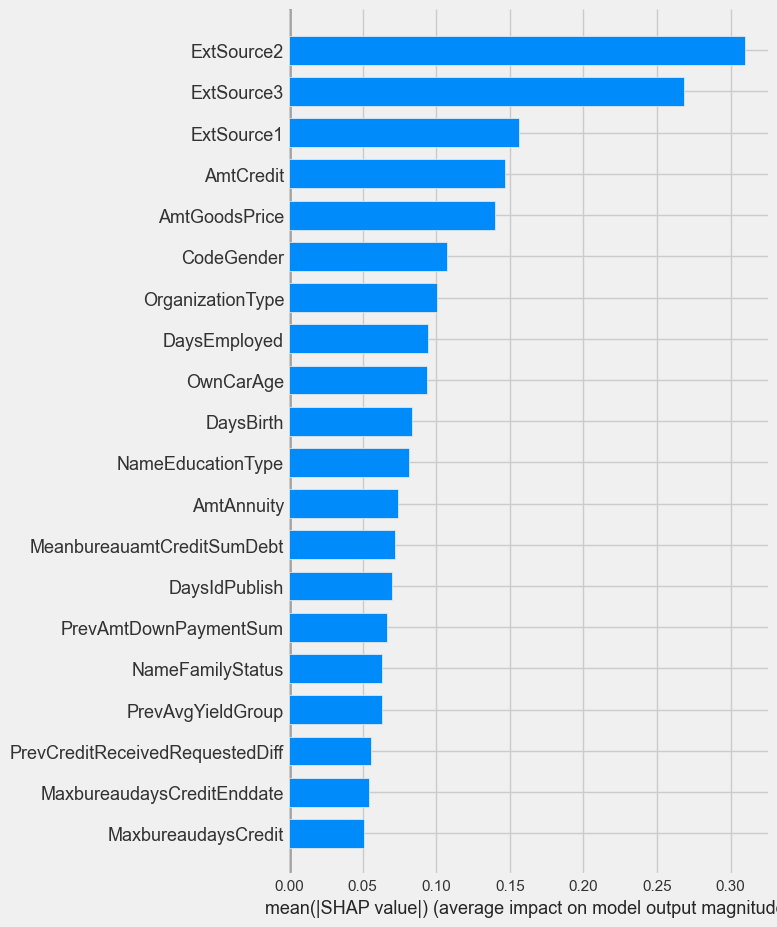

```python
explainer = shap.TreeExplainer(model)
shap_values = explainer.shap_values(X_test)
shap.summary_plot(shap_values, X_test, plot_type="bar")
```

```python
GENERATE_FEAT_IMP_LISTS = False

if GENERATE_FEAT_IMP_LISTS:
    if isinstance(shap_values, list):
        shap_abs_mean = np.abs(np.concatenate(shap_values, axis=0)).mean(axis=0)
    else:
        shap_abs_mean = np.abs(shap_values).mean(axis=0)

    feature_importances_df = pd.DataFrame(
        list(zip(X_test.columns, shap_abs_mean)), columns=["Feature", "Importance"]
    ).sort_values(by="Importance", ascending=False)

    low_imp = feature_importances_df[feature_importances_df["Importance"] < 0.002]
    low_imp = feature_importances_df[feature_importances_df["Importance"] < 0.002]

    ZERO_IMP_FEATURES = feature_importances_df[
        feature_importances_df["Importance"] < 0.001
    ]
    LOW_IMP_FEATURES = feature_importances_df[
        (feature_importances_df["Importance"] >= 0.001)
        & (feature_importances_df["Importance"] < 0.04)
    ]
    HIGH_IMP_FEATURES = feature_importances_df[
        feature_importances_df["Importance"] >= 0.04
    ]
    ANY_IMP_FEATURES = feature_importances_df[
        feature_importances_df["Importance"] >= 0.001
    ]

    LOW_IMP_FEATURES = list(LOW_IMP_FEATURES["Feature"])
    ANY_IMP_FEATURES = list(ANY_IMP_FEATURES["Feature"])
    ZERO_IMP_FEATURES = list(ZERO_IMP_FEATURES["Feature"])
    HIGH_IMP_FEATURES = list(HIGH_IMP_FEATURES["Feature"])

    print(f"ZERO_IMP_FEATURES: {len(ZERO_IMP_FEATURES)}")
    print(f"LOW_IMP_FEATURES: {len(LOW_IMP_FEATURES)}")
    print(f"HIGH_IMP_FEATURES: {len(HIGH_IMP_FEATURES)}")
    print(f"ANY_IMP_FEATURES: {len(ANY_IMP_FEATURES)}")

    all_feats = feature_builder_v2.load_datasets_and_prepare_features(
        drop_meta_data=True,
        ds_type=feature_builder_v2.DatasetType.FULL,
    )
    ALL_FEATS = list(all_feats.columns)
    ZERO_IMP_FEATURES = [
        feat for feat in ALL_FEATS if feat not in HIGH_IMP_FEATURES + LOW_IMP_FEATURES
    ]
```

### Calculating interest rates:

To determine interest rates for each loan while accounting for default risk and aiming to maximize total return on a portfolio, we can employ several advanced modeling techniques. Determening appropriate interest rates gennerally involves not only predicting the risk of default but also integrating this risk assessment into pricing strategies that reflect the level of risk associated with each loan.

We'll use a simple `Risk-Based Pricing Model`in our calculation: it directly links the interest rate charged on a loan to the estimated risk of default. The basic steps to build such a model are:

Additionally more complex models could (and probably should) be used in real world scenarios that would incorporate the market conditions (i.e. base interbank rates, margins offered by competitors etc.).

2. Profit Maximization Model This model focuses on maximizing the total return by considering both the interest income and the potential losses due to defaults.

Optimization Framework: Use an optimization model that calculates the optimal interest rate for each loan type. This model would use inputs from the risk model (PD and LGD) and incorporate constraints like minimum return requirements, risk appetite, and regulatory requirements. Simulation Techniques: Simulate different interest rate scenarios for various risk levels to determine the interest rate that maximizes profit while keeping the default risk within acceptable bounds.

3. Portfolio Approach Instead of setting rates on a loan-by-loan basis, consider the entire portfolio's risk and return.

Portfolio Diversification: Assess the risk contribution of each loan type to the overall portfolio and adjust interest rates to achieve desired diversification and risk-return profile. Risk-adjusted Return on Capital (RAROC): Utilize RAROC to evaluate the profitability of a loan, considering the capital at risk. RAROC is used to ensure that the adjusted return (considering risk) meets a certain threshold.

### Calibrating Probabilities

```python
display(Markdown(f"Mean. Model Predicted Probabilities = `{prob_pos.mean():.2%}`"))
display(
    Markdown(
        f"Actual Portfolio Default Rate = `{features_matrix['TARGET'].mean():.2%}`"
    )
)
```

Mean. Model Predicted Probabilities = `37.32%`

Actual Portfolio Default Rate = `8.07%`

We can't directly use the probabilities output by our model to perform any financial analysis because they are not aligned with the true probabilities, which is necessary for risk-based pricing models.

We'll have to calibrate our probabilities using `CalibratedClassifierCV` and using `Isotonic Regression` (A non-parametric approach that provides a piecewise linear calibration)

```python
from sklearn.calibration import CalibratedClassifierCV

importlib.reload(pipeline)
X_train_sub, X_calib, y_train_sub, y_calib = (
    pipeline.get_deterministic_train_test_split(
        features_matrix, include_calibration=True
    )
)

X_train_sub = X_train_sub.drop(columns=["TARGET"])
X_calib_target = X_calib["TARGET"]
X_calib = X_calib.drop(columns=["TARGET"])

model = selected_model.test_data.test_model.named_steps["model"]

calibrated_model = CalibratedClassifierCV(
    estimator=model, method="isotonic", cv="prefit"
)
y_calib_predictions = model.predict(X_calib)
calibrated_model.fit(X_calib, y_calib)
prob_pos_calibrated = calibrated_model.predict_proba(X_test)[:, 1]
```

```python
display(
    Markdown(
        f"Mean. Model Calibrated Probabilities = `{prob_pos_calibrated.mean():.2%}`"
    )
)
```

Mean. Model Calibrated Probabilities = `7.93%`

### Calculating hypothetical interest rates

We'll set the `LGD` to a constant value of 0.5. Generally `LGD` often ranges between 20% to 60% depending on the type of loan and collateral. For unsecured loans, LGD tends to be higher (closer to or exceeding 50%) due to the lack of recoverable assets.

```python
LGD = 0.5  # Example Loss Given Default percentages, should be adjusted to reflect actual data

# Parameters
cost_of_funds = 0.04  # e.g. Baseline interbank interest rate
profit_margin = 0.02  # Change based on actual data

# Calculate Expected Loss (EL) and actual loss (based on actual Y values)
EL = prob_pos_calibrated * LGD
real_L = y_test * LGD

# Calculate interest rates
interest_rates = cost_of_funds + EL + profit_margin
interest_rates_real = cost_of_funds + real_L + profit_margin

# Output results
print(f"Calibrated Probabilities mean:  {prob_pos_calibrated.mean():.2%}")
print(f"Loss Given Default (LGD):  {LGD}")
print(f"Expected Loss as % (EL):  {EL.mean():.3}")
print(f"Real Loss as % (EL):  {real_L.mean():.3}")
print(f"Average Interest Rates: {interest_rates.mean():.3%}")
print(f"Average Interest Rates: {interest_rates_real.mean():.3%}")
```

```
Calibrated Probabilities mean:  7.93%
Loss Given Default (LGD):  0.5
Expected Loss as % (EL):  0.0396
Real Loss as % (EL):  0.0404
Average Interest Rates: 9.963%
Average Interest Rates: 10.036%
```

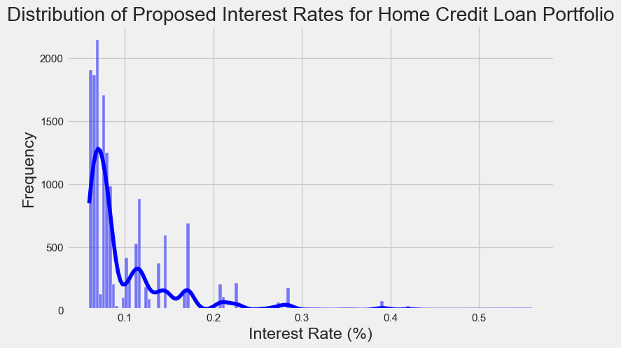

```python
plt.figure(figsize=(8, 5))
sns.histplot(interest_rates, kde=True, color="blue")
plt.title("Distribution of Proposed Interest Rates for Home Credit Loan Portfolio")
plt.xlabel("Interest Rate (%)")
plt.ylabel("Frequency")
plt.show()
```

### Asigning Loan Grades

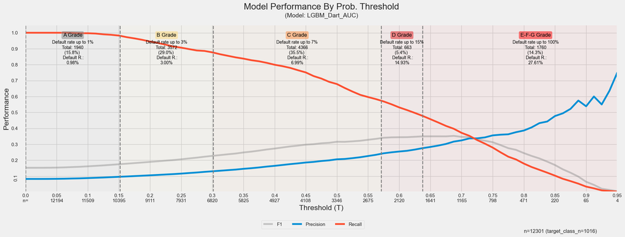

```python
import numpy as np
import pandas as pd

target_cm_data = selected_model.test_data
target_cm_data_sorted = target_cm_data.probabilities.sort_values(by=1).reset_index(
    drop=True
)
prediction_data = target_cm_data.probabilities.copy()
prediction_data["value"] = target_cm_data.y_test


def calculate_thresholds(prediction_data: pd.DataFrame) -> list:
    default_rates = {"A": 0.01, "B": 0.03, "C": 0.07, "D": 0.15, "E-F-G": 1.0}

    palette = sns.color_palette("YlOrRd", n_colors=len(default_rates) - 2)
    start_color = "grey"
    colors = [start_color] + palette + ["red"]

    prediction_data_sorted = prediction_data.sort_values(by=1, ascending=True)

    sections = []
    previous_threshold = 0.0
    color_index = 0

    for grade, max_default_rate in default_rates.items():
        remaining_loans = prediction_data_sorted[
            prediction_data_sorted[1] > previous_threshold
        ]

        remaining_loans["cumulative_defaults"] = remaining_loans["value"].cumsum()
        total_loans = np.arange(1, len(remaining_loans) + 1)
        remaining_loans["default_rate"] = (
            remaining_loans["cumulative_defaults"] / total_loans
        )

        valid_loans = remaining_loans[
            remaining_loans["default_rate"] <= max_default_rate
        ]
        if not valid_loans.empty:
            threshold = valid_loans[1].max()
        else:
            threshold = previous_threshold

        sections.append(
            {
                "label": f"{grade} Grade",
                "start": previous_threshold,
                "end": threshold,
                "color": colors[color_index],
                "description": f"Default rate up to {max_default_rate * 100:.0f}%",
            }
        )

        previous_threshold = threshold
        color_index += 1

    if sections:
        sections[-1]["end"] = 1.0

    return sections


sections = calculate_thresholds(prediction_data)
importlib.reload(stats_utils)
importlib.reload(graph)
summary_desc = "`The chart shows the  performance of the if only individual with stroke Prob. > T are selected. Additionally the overlay indicates the number of people whose predicted P is in an given range. The overlays can be used to selected the most at risk individual based on the probability predicted for them`"
from IPython.core.display import Markdown

graph.plot_threshold_metrics_v2(
    target_cm_data,
    0,
    1,
    sections=sections,
    model_name=SELECTED_MODEL_KEY,
    class_pos=1,
    include_vars=["f1", "precision", "recall"],
    show_threshold_n=True,
    log_x=False,
)
display(Markdown(summary_desc))
```

In the finance industry, loan grades (or credit scores) are a crucial part of risk management, helping lenders assess the creditworthiness of borrowers. These grades are typically determined based on various factors, including the borrower's credit history, income stability, debt-to-income ratio, and more. The grades reflect the estimated risk of default, and they directly influence the interest rate offered to the borrower. Commonly, loan grades are categorized from 'A' (lowest risk) to 'G' (highest risk), although the specific categories can vary by institution.

A (Lowest Risk): Below 1% default rate. Borrowers with excellent credit histories and very low risk of default. B: 1% to 3% default rate. Borrowers with good credit histories and low risk of default. C: 3% to 7% default rate. Borrowers with average credit histories and moderate risk of default. D: 7% to 15% default rate. Borrowers with below-average credit histories and higher risk of default. E: 15% to 25% default rate. Borrowers with poor credit histories and very high risk of default. F and G (Highest Risk): Above 25% default rate. Borrowers with very poor credit histories and extremely high risk of default.

```python
importlib.reload(local_utils)


def map_grade_prediction_based_on_prop_fact(sections):
    def map_grade_prediction_based_on_prop(row):
        for section in sections:
            if section["start"] <= row < section["end"]:
                return section["label"].replace(" Grade", "")
        return None  # Return None if no matching range is found

    return map_grade_prediction_based_on_prop


predicted_grades = prob_pos_series.map(
    map_grade_prediction_based_on_prop_fact(sections)
)

X_test_cp = X_test.copy()
X_test_cp["target__loan_status"] = y_test
X_test_cp["pass__int_rate"] = interest_rates

predictions_with_data = pd.concat(
    [
        X_test_cp,
        predicted_grades.to_frame(name="predicted_grades"),
    ],
    axis=1,
)
results = (
    predictions_with_data.groupby("predicted_grades")
    .apply(local_utils.calculate_metrics)
    .round(3)
)

display("Returns and Default Rate Based on Default Probability Model:")
results
```

```
'Returns and Default Rate Based on Default Probability Model:'
```

| predicted_grades | default_rate | mean_interest_rate | expected_return |
| --- | --- | --- | --- |
| A | 0.011 | 0.062 | 0.061 |
| B | 0.029 | 0.070 | 0.068 |
| C | 0.068 | 0.093 | 0.086 |
| D | 0.142 | 0.134 | 0.115 |
| E-F-G | 0.267 | 0.204 | 0.149 |

```python
def estimate_financial_improvement(data, predictions):
    """
    Estimate financial improvement by comparing actual financial metrics to hypothetical
    scenarios where loans predicted to default were not issued. Values requiring conversion
    to millions are converted upfront.

    Args:
    - data: DataFrame with actual loan data, including 'target__loan_status', 'pass__loan_amnt', and 'pass__int_rate'.
    - predictions: Series or list containing model predictions corresponding to the data.

    Returns:
    - DataFrame: A DataFrame containing both actual and hypothetical financial metrics, with appropriate formatting.
    """
    data_with_predictions = data.copy()
    data_with_predictions["predictions"] = predictions

    total_loan_amount_actual = (
        data["pass__loan_amnt"].sum() / 1_000_000
    )  # Convert to millions
    total_interest_paid_actual = (
        data.apply(
            lambda x: (
                (x["pass__loan_amnt"] * x["pass__int_rate"] / 100)
                if x["target__loan_status"] == 0
                else 0
            ),
            axis=1,
        ).sum()
        / 1_000_000
    )
    total_loss_actual = (
        data.loc[data["target__loan_status"] == 1, "pass__loan_amnt"].sum() / 1_000_000
    )
    total_return_percent_actual = (
        total_interest_paid_actual * 1_000_000 / (total_loan_amount_actual * 1_000_000)
    ) * 100

    # Calculations for hypothetical when using the model scenario
    hypothetical_data = data_with_predictions[data_with_predictions["predictions"] == 0]
    total_loan_amount_hypo = hypothetical_data["pass__loan_amnt"].sum() / 1_000_000
    total_interest_paid_hypo = (
        hypothetical_data.apply(
            lambda x: x["pass__loan_amnt"] * x["pass__int_rate"] / 100, axis=1
        ).sum()
        / 1_000_000
    )  # Convert to millions
    total_loss_hypo = (
        hypothetical_data.loc[
            hypothetical_data["target__loan_status"] == 1, "pass__loan_amnt"
        ].sum()
        / 1_000_000
    ) * LGD  # Convert to millions
    total_return_percent_hypo = (
        total_interest_paid_hypo * 1_000_000 / (total_loan_amount_hypo * 1_000_000)
    ) * 100  # Recalculate to correct percentage if total_loan_amount_hypo > 0 else 0

    losses_avoided = total_loss_actual - total_loss_hypo
    interest_lost = total_interest_paid_hypo - total_interest_paid_actual
    total_applications_actual = len(data)
    total_applications_hypo = len(hypothetical_data)

    improvement_metrics = {
        "Total Loan Amount": [
            f"{total_loan_amount_actual:.4f}M",
            f"{total_loan_amount_hypo:.4f}M",
        ],
        "Total Interest Paid": [
            f"{total_interest_paid_actual:.4f}M",
            f"{total_interest_paid_hypo:.4f}M",
        ],
        "Total Return %": [
            f"{total_return_percent_actual:.2f}%",
            f"{total_return_percent_hypo:.2f}%",
        ],
        "Default Rate": [
            f"{data_with_predictions['target__loan_status'].mean():.2%}",
            f"{hypothetical_data['target__loan_status'].mean():.2%}",
        ],
        "Total Loss": [f"{total_loss_actual:.4f}M", f"{total_loss_hypo:.4f}M"],
        "Losses Avoided": [None, f"{losses_avoided:.4f}M"],
        "Interest Lost": [None, f"{interest_lost:.4f}M"],
        "Total Applications Accepted": [
            total_applications_actual,
            total_applications_hypo,
        ],
    }

    improvement_df = pd.DataFrame(
        improvement_metrics, index=["Actual", "Hypothetical"]
    ).T

    return improvement_df
```

```python
transformed_data = X_calib.copy()
transformed_data

transformed_data["target__loan_status"] = X_calib_target
transformed_data["pass__loan_amnt"] = transformed_data["AmtCredit"]
transformed_data["pass__int_rate"] = interest_rates
transformed_data = transformed_data[
    ["target__loan_status", "pass__loan_amnt", "pass__int_rate"]
]
```

```python
prob_pos_calibrated
rounded_array = np.round(prob_pos_calibrated).astype(int)
```

#### Loan Acception Criteria and Profit Calculation

The final step we can attempt to is to try to calculate the hypothetical real return of Home Credit's loan portfolio if they used our model to employ a more conservative lending strategy (i.e. rejected all loans where the pre-calibrated default probability is > 0.5).

Again this is only an example because we are still using the interest rates calculated using the calibrated default probabilities should it should be replaced with actual interest rates from Home Credit's loan's to make the data actually meaningful.

```python
estimate_financial_improvement(transformed_data, y_calib_predictions)
```

|  | Actual | Hypothetical |
| --- | --- | --- |
| Total Loan Amount | 9243.9413M | 6911.6852M |
| Total Interest Paid | 8.5098M | 6.8729M |
| Total Return % | 0.09% | 0.10% |
| Default Rate | 7.97% | 2.90% |
| Total Loss | 683.7708M | 100.6901M |
| Losses Avoided | None | 583.0808M |
| Interest Lost | None | -1.6369M |
| Total Applications Accepted | 15376 | 11041 |

#### Explainability

We've used LGBM which is relatively complex "blackbox" model which might not be the ideal in loan evaluations and similar tasks because it's hard to objectively explain the specific decisions the model made (based on regulatory or customer related requirements).

However, we believe that we were largely able to overcome this shortcoming through the use of single observation SHAP plots:

they allow us to attribute the impact of specific feature (e.g. credit scores, client income etc.) on the estimated risk which allows to select an appropriate grade, interest rate and decide whether the loan should or should not be approved based on our acceptable risk preferences:

Each plotted line explains a single model prediction.

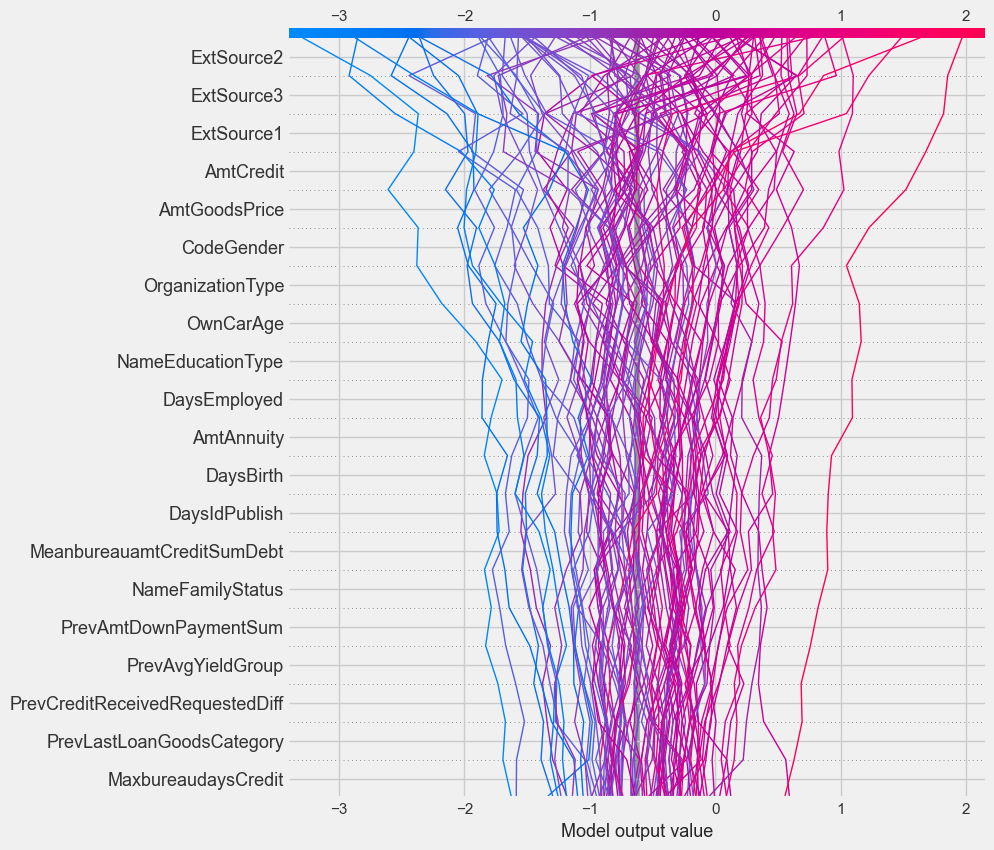

```python
num_samples = 100

indices = np.random.choice(X_test.shape[0], num_samples, replace=False)

shap_values_subsample = shap_values[indices]
X_test_subsample = X_test.iloc[indices]

shap.decision_plot(
    explainer.expected_value,
    shap_values_subsample,
    X_test_subsample,
    ignore_warnings=True,
)
```

The chart above visualizes the model predictions process for individual observations (for a subsample of 100 loans). For a single sample, the line charts the path from the base value to the final predicted value. ach feature causes the line to shift up or down. This shift is determined by its SHAP value. indicates a feature pushing the prediction higher, while blue indicates it pushes the prediction lower.

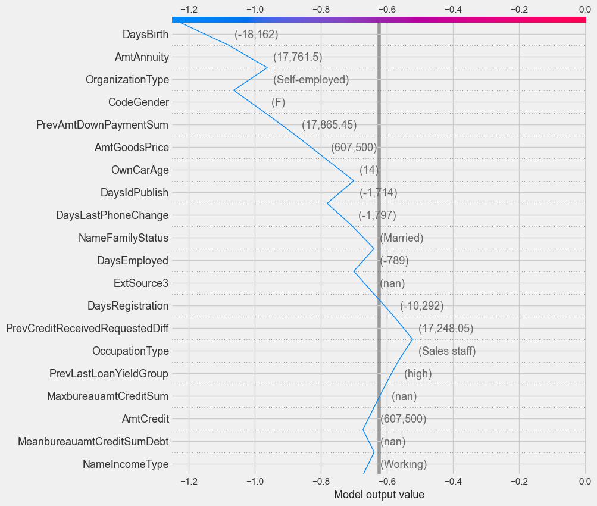

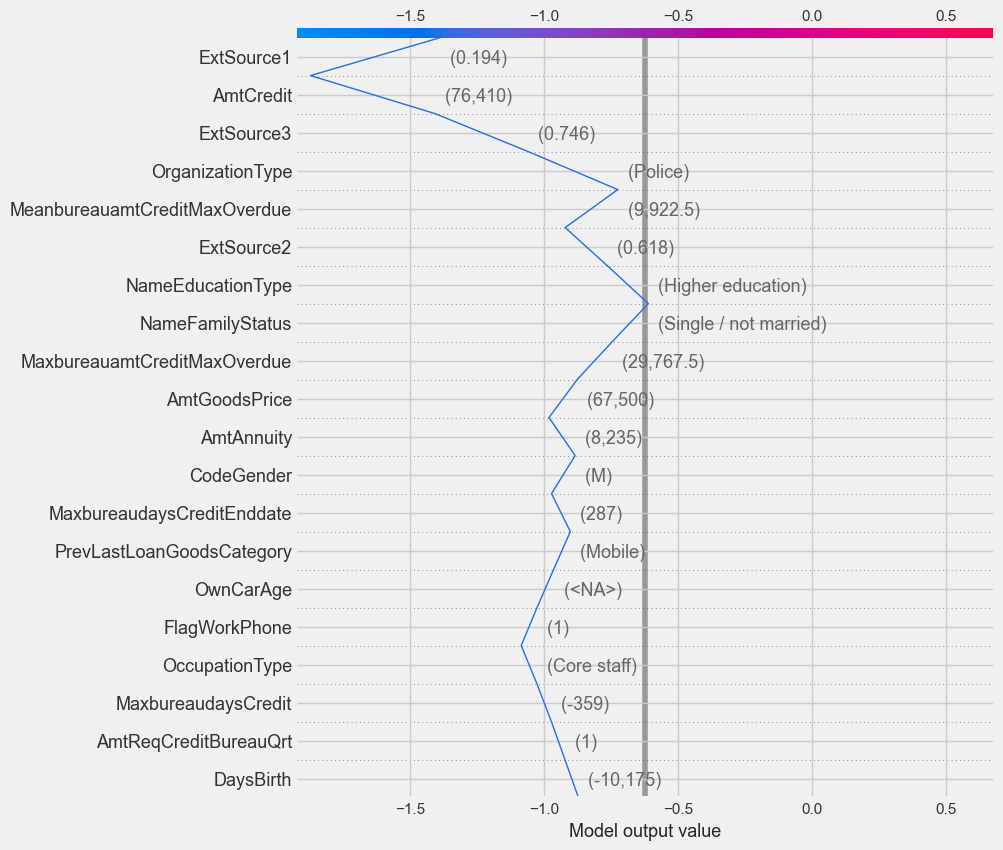

```python
import numpy as np

num_samples = 100

indices = np.random.choice(X_test.shape[0], num_samples, replace=False)

shap_values_subsample = shap_values[indices]
X_test_subsample = X_test.iloc[indices]

specific_indices = [0, 1]

for idx in specific_indices:
    shap.decision_plot(
        explainer.expected_value,
        shap_values_subsample[idx],
        features=X_test_subsample.iloc[idx],
        feature_names=X_test.columns.tolist(),
        ignore_warnings=True,
    )
```

```python
import numpy as np

predicted_probabilities = model.predict_proba(X_test)[:, 1]

absolute_differences = np.abs(predicted_probabilities - y_test)

differences_df = pd.DataFrame(
    {"absolute_difference": absolute_differences, "index": range(len(y_test))}
)

N = 10
top_differences_df = differences_df.nlargest(N, "absolute_difference")

random_sample_top_diff = top_differences_df.sample(n=N, random_state=42)

selected_indices = random_sample_top_diff["index"].values

selected_samples_X_test = X_test.iloc[selected_indices]
selected_samples_y_test = y_test.iloc[selected_indices]
```